# R Lab: Simple Linear Regression

STA 631 – Statistical Modeling I

Author

Andrew DiLernia

Once completed, submit a zipped file (.zip) containing two total documents via Blackboard: a .qmd Quarto file and the corresponding HTML document.

## 1.

Load the state-level ACS data for 2021 into R from this URL: https://raw.githubusercontent.com/dilernia/STA631/refs/heads/main/data/census_data_state_2008-2021.csv.

## 2.

Reproduce the scatter plot below, including a straight-line of best fit showing the percent of people in poverty (`perc_poverty`) by the median income in thousands of dollars for each state (`median_income_thousand`).

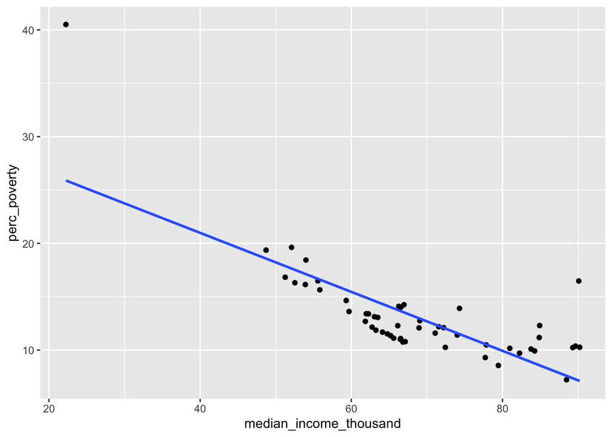

## 3.

Fit a simple linear regression model with median income in thousands of dollars as the predictor variable and percent poverty as the response variable.

## 4.

Reproduce the model output displayed below. *Hint*: pay careful attention to potential rounding in the table.

| **Characteristic** | **Beta** | **95% CI** | **p-value** |
| --- | --- | --- | --- |
| (Intercept) | 32 | 27, 37 | <0.001 |
| median_income_thousand | -0.28 | -0.34, -0.21 | <0.001 |

Abbreviation: CI = Confidence Interval

## 5.

Provide a statement of the estimated regression equation based on the model output.

## 6.

Provide the value of and interpret the estimated slope in context.

## 7.

Provide the value of and interpret the estimated intercept in context. Is this appropriate here? Why or why not?

## 8.

Create and display diagnostic plots for the simple linear regression model, including the Residuals vs Fitted plot, the Normal Q-Q plot, histogram of the residuals, Cook’s distance plot, and the Residuals vs Leverage plot.

## 9.

State and check if each assumption for fitting a simple linear regression model is met, providing specific evidence to support your conclusions from the R output obtained.

## 10.

Are there any influential points? If so, how many are there? Cite specific evidence to support your conclusion.

## 11.

Are there any outliers? If so, how many are there? Cite specific evidence to support your conclusion.

## 12.

Regardless of whether or not assumptions are met, formally state the hypotheses for testing if the regression slope is 0 or not.

## 13.

Provide the test statistic, p-value, and decision for this hypothesis test.

## 14.

Interpret the results of the hypothesis test in the context of the problem.